# Ssec Scores: Partial Correlation

Angela Yoder

2022-06-28

### Theory

Partial Correlation: Adjusts for confounders in correlation. These are calculated via the function ggm.estimate.pcor from the GeneNet package via shrinkage? according to methods established in Schafer and Strimmer (2005). These allow for calculation of correlation for datasets where there are more variables than subjects, as is common in genetics data.

Biweight Midcorrelation: semi-parametric median-based correlation measure which is not susceptible to outliers. [I could do a sensitivity analysis to see how influential outliers could be within Ssec measure for pacor v. bicor? “Fast R Functions for Robust Correlations and Hierarchical Clustering”]

### Pearson Correlation Comparison

Ssec scores calculated with Pearson Correlation are fairly similar to Ssec scores calculated with biweight midcorrelation. Ssec scores calculated with partial correlation are significantly different from both pearson ssec scores and bicor ssec scores.

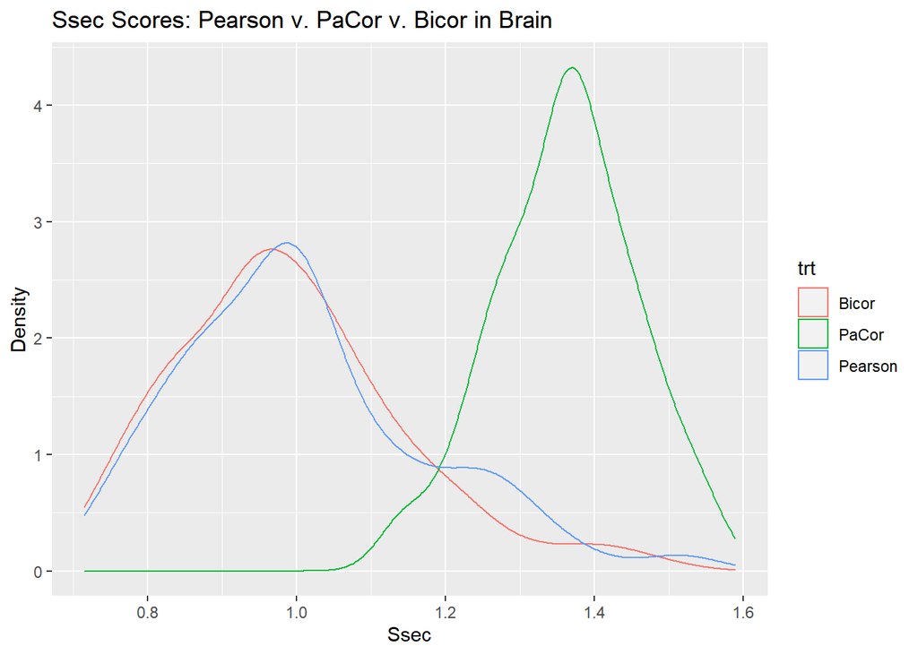

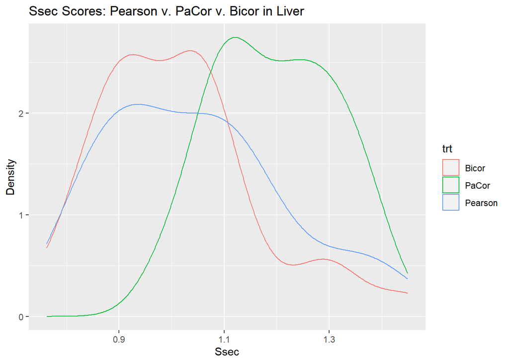

### Direct Comparisons

Looking at the ranked Ssec scores for those calculated with biweight midcorrelation and partial correlation, they appear to be flipped. The highest ssec scores for bicor are some of the lowest ssec scores for pacor (dark red, red, orange, yellow). The highest ssec scores for pacor are some the lowest ssec scores for bicor (light green, green, light blue, blue).

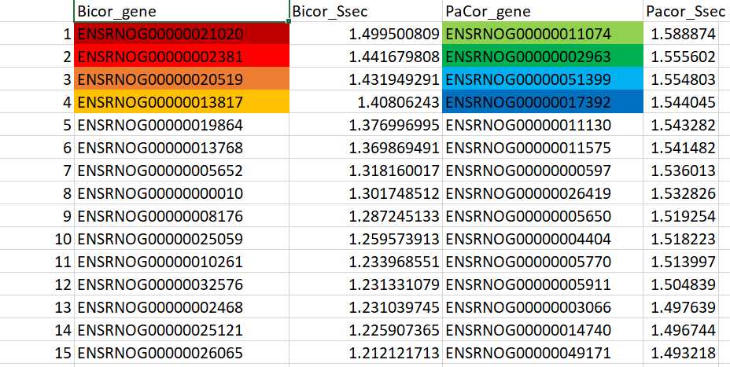

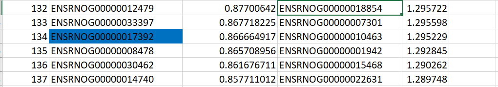

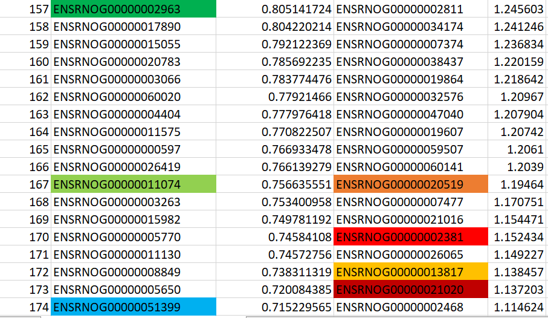

### Comparing Correlation Values and P-values

The following tables and graphs show very little variability in the partial correlation values, compared to biweight midcorrelation values. The p-values on the other hand, match much more closely.

```
## [1] 86
```

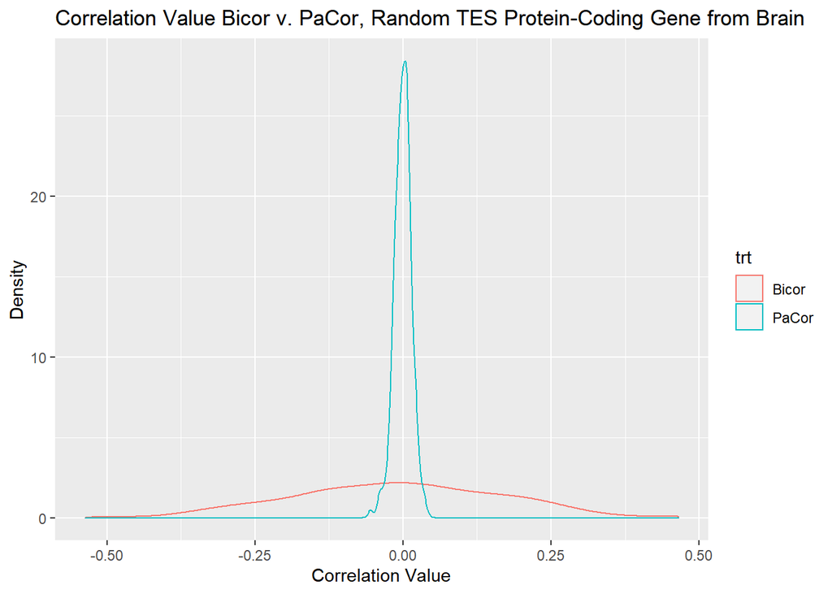

```
## [1] 30
```

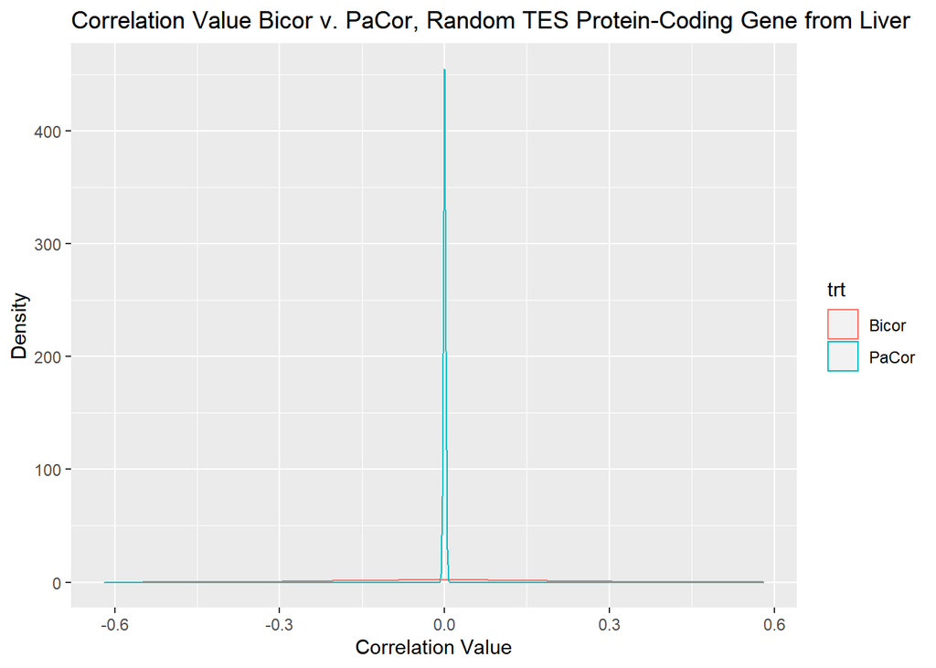

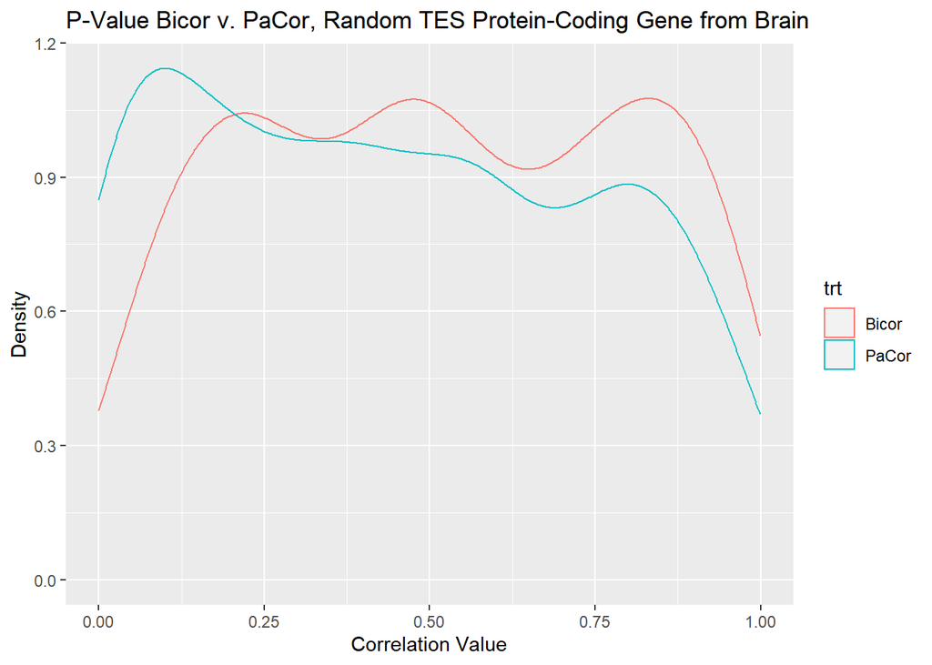

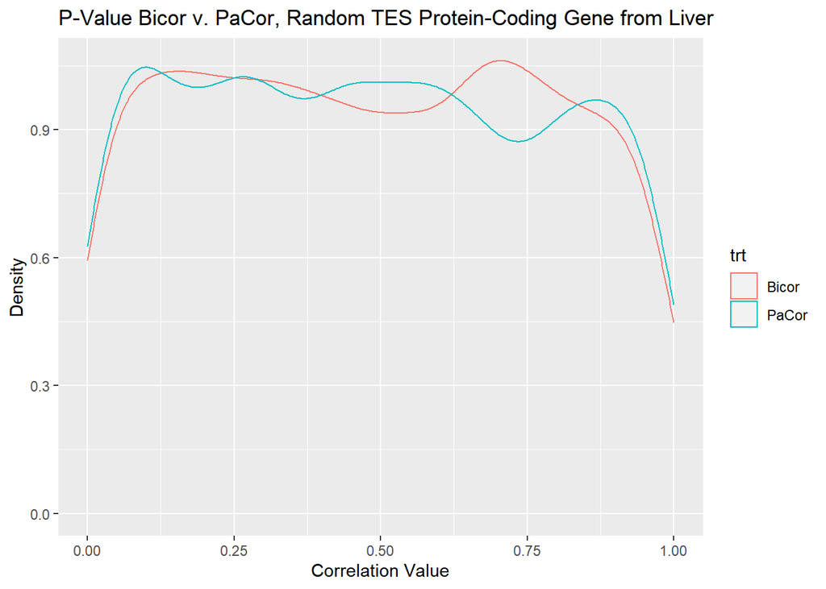

### Distribution of Ssec Scores

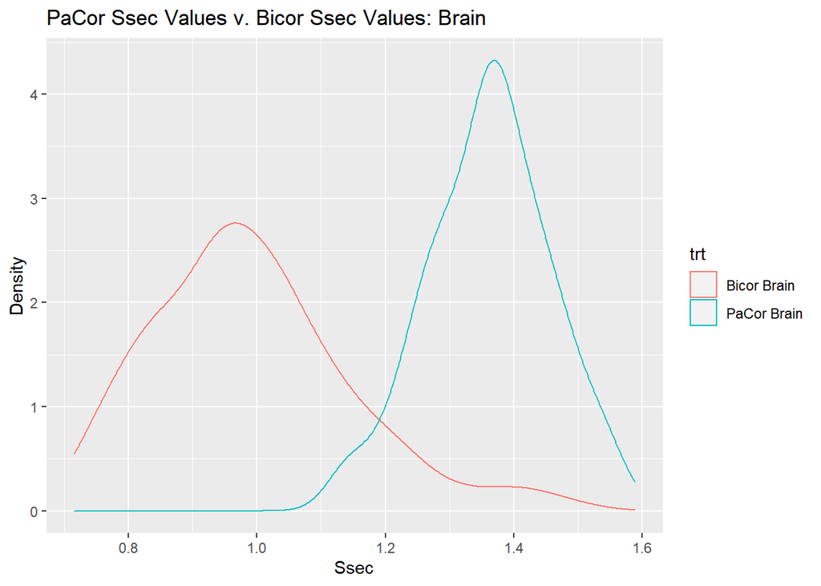

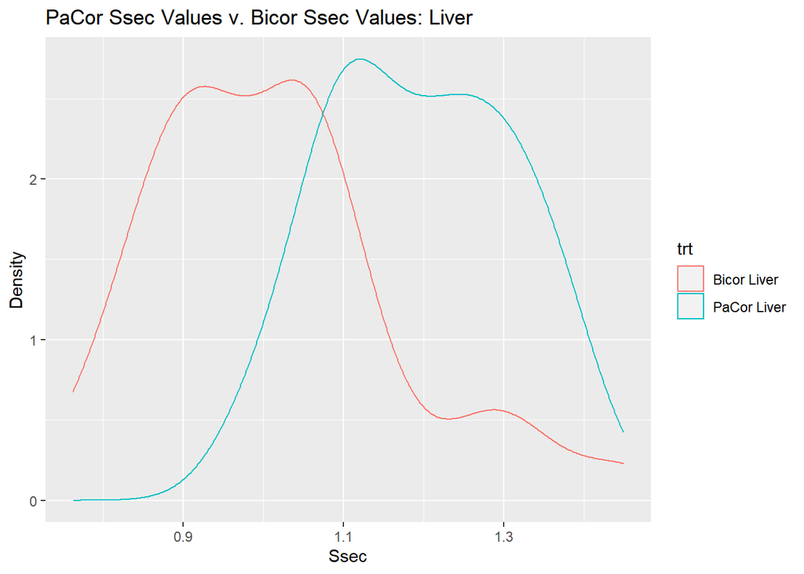

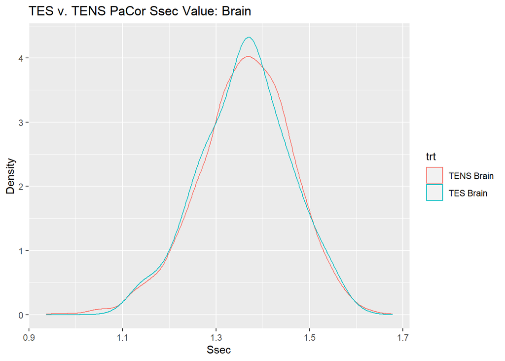

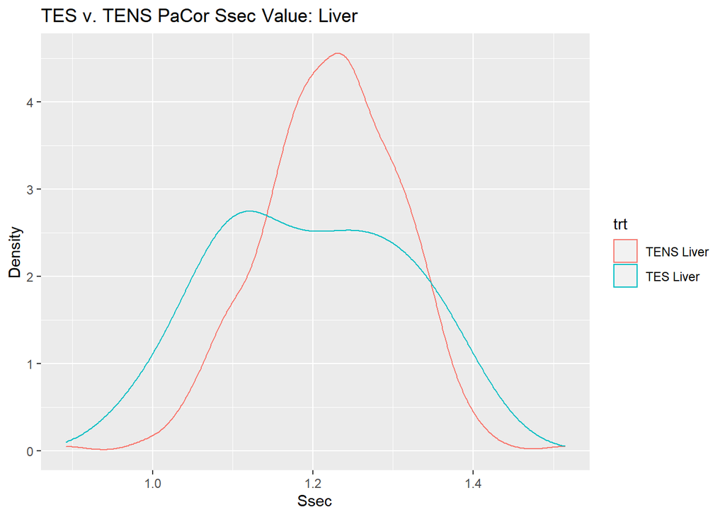

### QQ Plots

#### PACOR SSEC SCORE

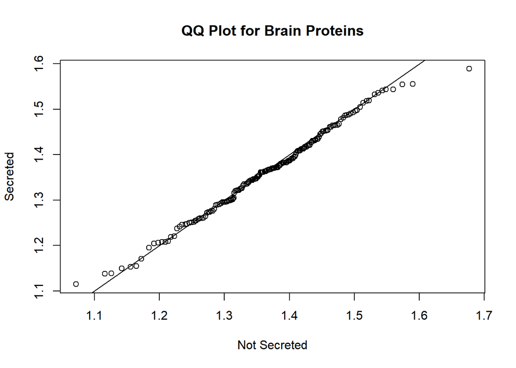

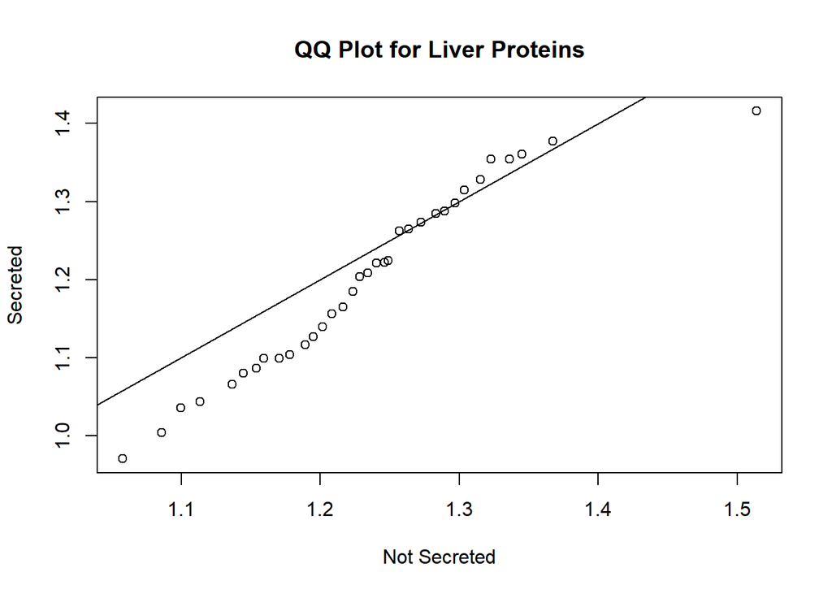

#### BICOR SSEC SCORE

From QQ Plots.Rmd

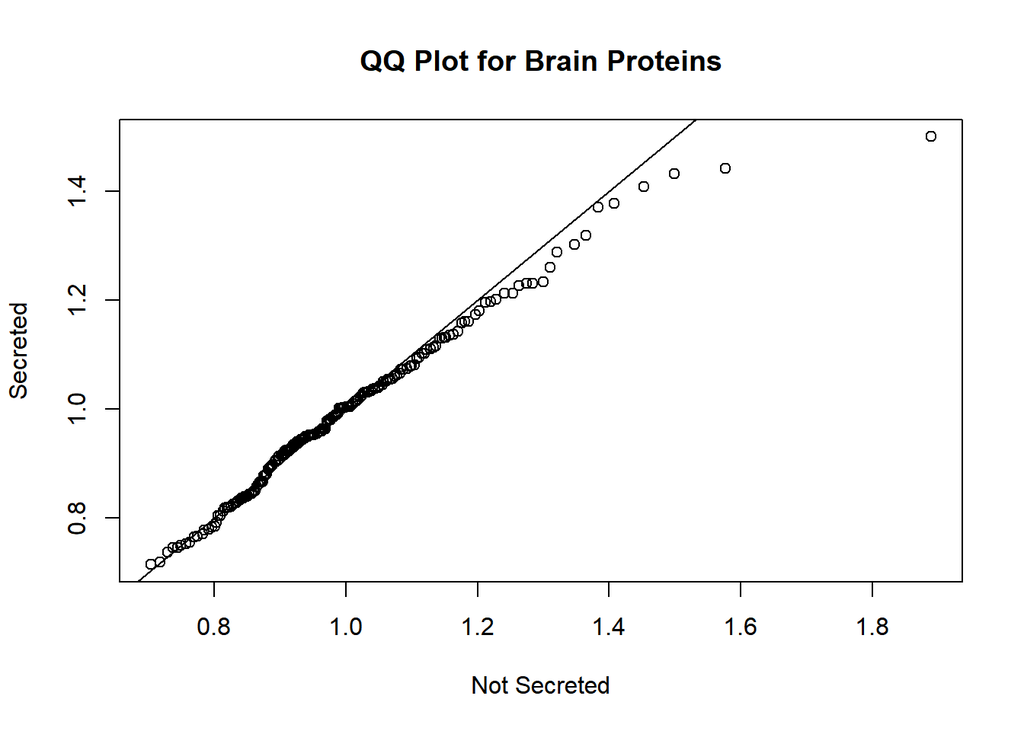

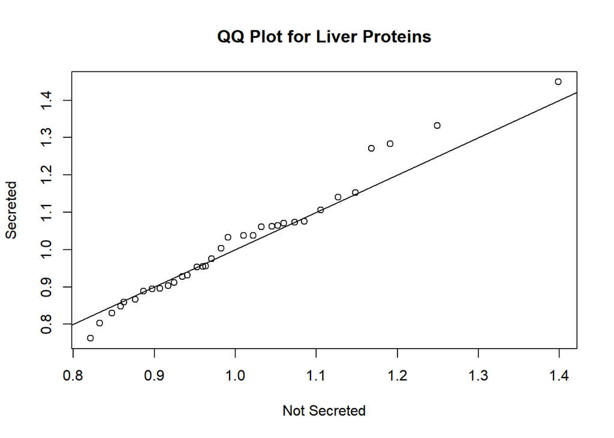